# Natural Language Processing

## Twitter Sentiment Analysis

- In this module we will be running sentiment analysis on tweets. At UChicago we have the entire tweet corpus which has information pertaining to all the tweets, which are being scraped. In this module I segregate UChicago and NUs tweets to understand how and what the crowd sentiment is towards the two schools
- We will check what the majority of the audience is tweeting about when it comes to these two schools
- We will map the tweets as per the location and then see where the tweets are coming from throughout the globe
- We will do some basic topic modelling to segregate the tweets into different types

In this module I have already segregated the tweets related to UChicago and NU using various hashtags and then after some data cleaning I am using that data set for the anlaysis

Please check the other module which has been used to obtain these tweets.

Note: the column names are fairly intuitive to understand

```python
import numpy as np
import pandas as pd
import datetime
import matplotlib.pyplot as plt
import matplotlib
%matplotlib inline
```

```python
path = "/Users/mayank/Documents/College Documents/Q3 Courses/Big Data/Files_Aditi/"
input_file = path+"concat.csv"
df_concat = pd.read_csv(input_file)
```

### Identify the most prolific / influential Twitter users

- By message volume
- By message retweet

```python
df_concat.head(5)
```

|  | text | created_at | favorite_count | id | in_reply_to_screen_name | in_reply_to_user_id | is_quote_status | possibly_sensitive | quote_count | lang | ... | user.verified | user.followers_count | user.listed_count | user.friends_count | user.favourites_count | user.statuses_count | user.created_at | user.lang | College_ID | text_clean |
| --- | --- | --- | --- | --- | --- | --- | --- | --- | --- | --- | --- | --- | --- | --- | --- | --- | --- | --- | --- | --- | --- |
| 0 | Non-UChicago people ignore this tweet...\nTHE ... | Thu Jun 22 23:28:13 +0000 2017 | 0.0 | 8.780319e+17 | NaN | NaN | False | False | NaN | en | ... | False | 420.0 | 54.0 | 390.0 | 10430.0 | 5739.0 | Sun Apr 10 21:22:34 +0000 2016 | en | UChicago | NonUChicago people ignore this tweet...THE IOP... |
| 1 | the four uchicago dress senses: business casua... | Thu Jun 22 23:33:37 +0000 2017 | 0.0 | 8.780333e+17 | NaN | NaN | False | NaN | NaN | en | ... | False | 103.0 | 1.0 | 152.0 | 4158.0 | 558.0 | Mon May 30 07:00:16 +0000 2016 | en | UChicago | the four uchicago dress senses: business casua... |
| 2 | RT @HdxAcademy: We congratulate @UChicago &amp... | Thu Jun 22 23:36:01 +0000 2017 | 0.0 | 8.780339e+17 | NaN | NaN | False | NaN | NaN | en | ... | False | 33.0 | 0.0 | 463.0 | 225.0 | 101.0 | Sun Jan 01 17:53:34 +0000 2017 | en | UChicago | RT @HdxAcademy: We congratulate @UChicago amp ... |
| 3 | Great visit from @UChicago students #PaulSeren... | Thu Jun 22 23:42:33 +0000 2017 | 0.0 | 8.780355e+17 | NaN | NaN | False | False | NaN | en | ... | False | 293.0 | 7.0 | 243.0 | 156.0 | 120.0 | Tue May 30 15:03:03 +0000 2017 | en | UChicago | Great visit from @UChicago students #PaulSeren... |
| 4 | #thursdaythought: “Shadowing attorneys this we... | Thu Jun 22 23:43:41 +0000 2017 | 0.0 | 8.780358e+17 | NaN | NaN | False | NaN | NaN | en | ... | False | 454.0 | 24.0 | 761.0 | 295.0 | 773.0 | Sat Sep 04 00:15:53 +0000 2010 | en | UChicago | #thursdaythought: Shadowing attorneys this wee... |

5 rows × 36 columns

```python
list(df_concat.columns.values)
```

```
['text',
 'created_at',
 'favorite_count',
 'id',
 'in_reply_to_screen_name',
 'in_reply_to_user_id',
 'is_quote_status',
 'possibly_sensitive',
 'quote_count',
 'lang',
 'reply_count',
 'retweet_count',
 'timestamp_ms',
 'coordinates',
 'entities',
 'place',
 'user',
 'coordinates.coordinates',
 'entities.hashtags',
 'place.country',
 'place.country_code',
 'place.full_name',
 'place.id',
 'place.place_type',
 'user.id',
 'user.screen_name',
 'user.verified',
 'user.followers_count',
 'user.listed_count',
 'user.friends_count',
 'user.favourites_count',
 'user.statuses_count',
 'user.created_at',
 'user.lang',
 'College_ID',
 'text_clean']
```

```python
len(df_concat)
#the input file should have 203357 (132164+71193) entries, and since it does not have that I will remove the columns
#with more than 5 missing entries
```

```
230976
```

```python
df_concat.dropna(thresh=5,inplace=True)
len(df_concat)
#we now see that the input file has proper number of entries
```

```
203357
```

### Top tweeters for UChicago by number of tweets

```python
#BY VOLUME
#calculating the users who have tweeted mostly about the topics sub-setted above
top_users_vol=df_concat[df_concat.College_ID=="UChicago"].groupby(["user.screen_name"],as_index=False)['text']\
            .count().sort_values('text', ascending=False )\
            .rename(columns={"text":"tweet_count"})
top_users_vol.head(10)
```

|  | user.screen_name | tweet_count |
| --- | --- | --- |
| 68036 | uchicagogsu | 965 |
| 32560 | UChicago | 857 |
| 6570 | ChicagoMaroons | 725 |
| 19573 | LyoLouisJacques | 500 |
| 47839 | haileysecretary | 367 |
| 8257 | DanW_BCI | 340 |
| 64939 | sofiaorden | 311 |
| 58081 | n8taki | 284 |
| 69086 | wendchain | 283 |
| 3874 | BeckerFriedman | 280 |

### Top tweeters for Northwestern by number of tweets

```python
#BY VOLUME
#calculating the users who have tweeted mostly about the topics sub-setted above
top_users_vol=df_concat[df_concat.College_ID=="Northwestern"].groupby(["user.screen_name"],as_index=False)['text']\
            .count().sort_values('text', ascending=False )\
            .rename(columns={"text":"tweet_count"})
top_users_vol.head(10)
```

|  | user.screen_name | tweet_count |
| --- | --- | --- |
| 9451 | ISENatNU | 349 |
| 8137 | GamerGeekNews | 267 |
| 17999 | ResearchNU | 261 |
| 12276 | LIVE_COVERAGE | 156 |
| 16040 | NorthwesternU | 151 |
| 32735 | jmkuhn99 | 142 |
| 20998 | TheGarageNU | 119 |
| 36181 | micheleweldon | 112 |
| 37672 | nu_digitallearn | 108 |
| 7336 | EvanstonPokemon | 102 |

### Top tweeters for UChicago by number of retweets

```python
df_concat['retweet_count'].describe()
#df_concat.retweet_count.drop_duplicates
```

```
count    203357.0
mean          0.0
std           0.0
min           0.0
25%           0.0
50%           0.0
75%           0.0
max           0.0
Name: retweet_count, dtype: float64
```

```python
#BY RETWEETS
#calculating the users who have tweeted mostly about the topics sub-setted above
top_users_re=df_concat[(df_concat.College_ID=="UChicago") & (df_concat.retweet_count > 0)]\
            .groupby(["user.screen_name"],as_index=False)['retweet_count']\
            .count().sort_values('retweet_count', ascending=False )\
            .rename(columns={"retweet_count":"retweet_count"})
top_users_re.head(10)
```

|  | user.screen_name | retweet_count |
| --- | --- | --- |

From the above result we see that there has been no retweets

```python
#BY RETWEETS
#calculating the users who have tweeted mostly about the topics sub-setted above
top_users_re=df_concat[(df_concat.College_ID=="Northwestern") & (df_concat.retweet_count > 0)]\
            .groupby(["user.screen_name"],as_index=False)['retweet_count']\
            .count().sort_values('retweet_count', ascending=False )\
            .rename(columns={"retweet_count":"retweet_count"})
top_users_re.head(10)
```

|  | user.screen_name | retweet_count |
| --- | --- | --- |

The same can be observed about NU.

#### We can check the most influential tweeters from the number of tweets that have been favorited

```python
#BY FAVORITES
#calculating the users who have tweeted mostly about the topics sub-setted above
top_users_re=df_concat[(df_concat.College_ID=="UChicago") & (df_concat.favorite_count > 0)].groupby(["user.screen_name"],as_index=False)['retweet_count']\
            .count().sort_values('retweet_count', ascending=False )\
            .rename(columns={"retweet_count":"retweet_count"})
top_users_re.head(10)
```

|  | user.screen_name | retweet_count |
| --- | --- | --- |

## Where are these authors located?

- For UChicago
- For other universities
- Do you see any relationship between university locations and authors locations?
- Visualize the relationships

```python
top_users_loc=df_concat[df_concat.College_ID=="UChicago"].groupby(["place.country"],as_index=False)['place.full_name'].count()\
        .sort_values('place.full_name',ascending=False).reset_index(drop=True)\
        .rename(columns={"place.full_name":"tweet_count"})
top_users_loc.head(10)
```

|  | place.country | tweet_count |
| --- | --- | --- |
| 0 | United States | 2470 |
| 1 | Canada | 142 |
| 2 | India | 34 |
| 3 | United Kingdom | 20 |
| 4 | Estados Unidos | 15 |
| 5 | Sweden | 7 |
| 6 | South Africa | 7 |
| 7 | Australia | 6 |
| 8 | Germany | 6 |
| 9 | Türkiye | 4 |

#### Now we will check how the tweets are distributed across the United States

```python
pd.DataFrame((df_concat[df_concat.College_ID=="UChicago"])["place.full_name"].value_counts().head(10))
#pd.DataFrame(df_concat["place.full_name"].value_counts().head(10))
```

|  | place.full_name |
| --- | --- |
| Chicago, IL | 1286 |
| Calgary, Alberta | 95 |
| The University of Chicago | 45 |
| Washington, DC | 44 |
| Manhattan, NY | 39 |
| Cincinnati, OH | 33 |
| Los Angeles, CA | 28 |
| Evanston, IL | 27 |
| Boston, MA | 20 |
| Philadelphia, PA | 19 |

We see that most of the tweets have been from Chicago

### Checking the authors distribution for Northwestern

```python
top_users_loc=df_concat[df_concat.College_ID=="Northwestern"].groupby(["place.country"],as_index=False)['place.full_name'].count()\
        .sort_values('place.full_name',ascending=False).reset_index(drop=True)\
        .rename(columns={"place.full_name":"tweet_count"})
top_users_loc.head(10)
```

|  | place.country | tweet_count |
| --- | --- | --- |
| 0 | United States | 1878 |
| 1 | Republic of the Philippines | 78 |
| 2 | Canada | 16 |
| 3 | United Kingdom | 15 |
| 4 | Qatar | 12 |
| 5 | Australia | 9 |
| 6 | Estados Unidos | 7 |
| 7 | Germany | 7 |
| 8 | Republika ng Pilipinas | 6 |
| 9 | France | 5 |

```python
#checking how the tweets have been distributed across the US
pd.DataFrame((df_concat[df_concat.College_ID=="Northwestern"])["place.full_name"].value_counts().head(10))
#pd.DataFrame(df_concat["place.full_name"].value_counts().head(10))
```

|  | place.full_name |
| --- | --- |
| Evanston, IL | 508 |
| Chicago, IL | 340 |
| Northwestern University | 39 |
| Laoag City, Ilocos Region | 37 |
| Dagupan City, Ilocos Region | 32 |
| Los Angeles, CA | 31 |
| Washington, DC | 30 |
| Manhattan, NY | 30 |
| Illinois, USA | 16 |
| San Francisco, CA | 16 |

## What distinguishes University of Chicago authors vs authors who tweet about other universities

- Visualize the trends as per the date

```python
df_concat["created_at"].head(10)
```

```
0    Thu Jun 22 23:28:13 +0000 2017
1    Thu Jun 22 23:33:37 +0000 2017
2    Thu Jun 22 23:36:01 +0000 2017
3    Thu Jun 22 23:42:33 +0000 2017
4    Thu Jun 22 23:43:41 +0000 2017
5    Thu Jun 22 23:48:16 +0000 2017
6    Thu Jun 22 23:59:27 +0000 2017
7    Fri Jun 23 00:30:04 +0000 2017
8    Fri Jun 23 00:32:25 +0000 2017
9    Fri Jun 23 00:35:54 +0000 2017
Name: created_at, dtype: object
```

```python
type(df_concat["created_at"])
```

```
pandas.core.series.Series
```

```python
df_concat['date']=pd.to_datetime(df_concat["created_at"]).dt.date
```

```python
df_concat["date"].head(10)
```

```
0    2017-06-22
1    2017-06-22
2    2017-06-22
3    2017-06-22
4    2017-06-22
5    2017-06-22
6    2017-06-22
7    2017-06-23
8    2017-06-23
9    2017-06-23
Name: date, dtype: object
```

```python
#calculating the number of tweets as per the day
df_concat_day = df_concat[df_concat.College_ID=="UChicago"].groupby('date',as_index=False)['text'].count()\
        .sort_values('text',ascending=False).reset_index(drop=True)\
        .rename(columns={"text":"tweet_count"})
```

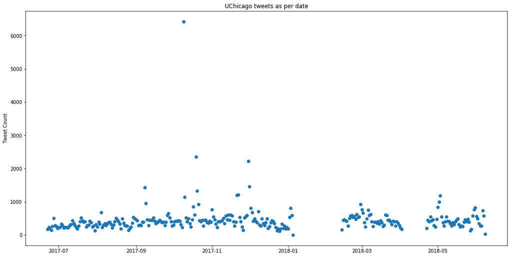

```python
plt.rcParams['figure.figsize'] = [18, 9]
_=plt.plot_date(matplotlib.dates.date2num(df_concat_day['date']),df_concat_day['tweet_count'])
plt.ylabel("Tweet Count")
plt.title("UChicago tweets as per date")
plt.show()
```

#### Creating the same chart for Northwestern

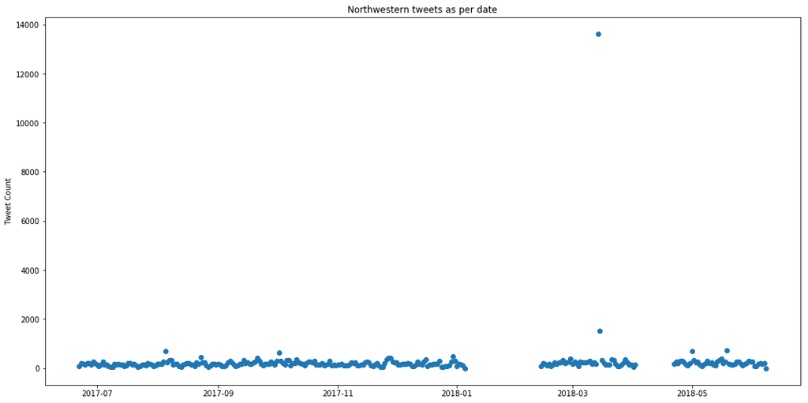

```python
#calculating the number of tweets as per the day
df_concat_day = df_concat[df_concat.College_ID=="Northwestern"].groupby('date',as_index=False)['text'].count()\
        .sort_values('text',ascending=False).reset_index(drop=True)\
        .rename(columns={"text":"tweet_count"})

plt.rcParams['figure.figsize'] = [18, 9]
_=plt.plot_date(matplotlib.dates.date2num(df_concat_day['date']),df_concat_day['tweet_count'])
plt.ylabel("Tweet Count")
plt.title("Northwestern tweets as per date")
plt.show()
```

## What are the timelines of these tweets? Do you see significant peaks and valleys? Do you see data collection gaps?

Visualizing the tweet times and number of tweets sent on an hourly basis

```python
df_concat['hour']=(pd.to_datetime(df_concat["created_at"]).dt.hour)*1
df_concat["hour"].head(10)
```

```
0    23
1    23
2    23
3    23
4    23
5    23
6    23
7     0
8     0
9     0
Name: hour, dtype: int64
```

```python
#calculating the number of tweets as per the hour
df_concat_hour = df_concat[df_concat.College_ID=="UChicago"].groupby('hour',as_index=False)['text'].count()\
        .sort_values('hour',ascending=True).reset_index(drop=True)\
        .rename(columns={"text":"tweet_count"})
```

```python
type(df_concat_hour["hour"])
```

```
pandas.core.series.Series
```

```python
df_concat_hour
```

|  | hour | tweet_count |
| --- | --- | --- |
| 0 | 0 | 5996 |
| 1 | 1 | 5668 |
| 2 | 2 | 5092 |
| 3 | 3 | 4717 |
| 4 | 4 | 3730 |
| 5 | 5 | 3301 |
| 6 | 6 | 2263 |
| 7 | 7 | 1829 |
| 8 | 8 | 1619 |
| 9 | 9 | 2139 |
| 10 | 10 | 2872 |
| 11 | 11 | 2898 |
| 12 | 12 | 4061 |
| 13 | 13 | 6239 |
| 14 | 14 | 7382 |
| 15 | 15 | 7996 |
| 16 | 16 | 8650 |
| 17 | 17 | 8740 |
| 18 | 18 | 8401 |
| 19 | 19 | 8020 |
| 20 | 20 | 8599 |
| 21 | 21 | 7827 |
| 22 | 22 | 7250 |
| 23 | 23 | 6875 |

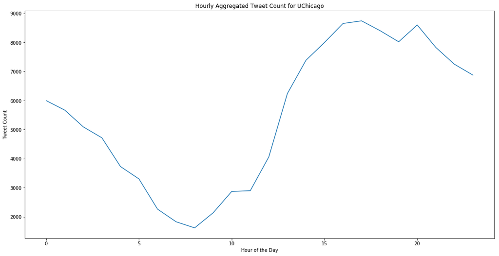

```python
plt.plot(df_concat_hour["hour"],df_concat_hour["tweet_count"])
plt.xlabel("Hour of the Day")
plt.ylabel("Tweet Count")
plt.title("Hourly Aggregated Tweet Count for UChicago")
plt.show()
```

```python
df_concat_hour
```

[output not shown]

#### Repeating the same analysis for NU

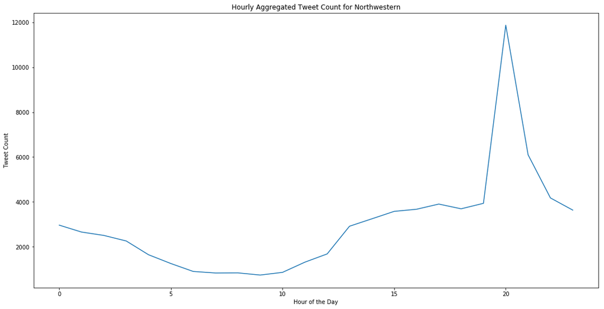

```python
#calculating the number of tweets as per the hour
df_concat_hour = df_concat[df_concat.College_ID=="Northwestern"].groupby('hour',as_index=False)['text'].count()\
        .sort_values('hour',ascending=True).reset_index(drop=True)\
        .rename(columns={"text":"tweet_count"})
plt.plot(df_concat_hour["hour"],df_concat_hour["tweet_count"])
plt.xlabel("Hour of the Day")
plt.ylabel("Tweet Count")
plt.title("Hourly Aggregated Tweet Count for Northwestern")
plt.show()
```

### Visualizing the tweets and location

```python
df_concat["coordinates.coordinates"].value_counts().head(10)
```

```
[-87.67563675, 42.05315833]    134
[-87.60040946, 41.79003304]    104
[-87.67688831, 42.05786515]     35
[120.33039434, 16.03580267]     33
[-87.67565489, 42.05307981]     32
[-87.6005291, 41.79012569]      25
[120.56831069, 18.18656669]     25
[-87.60460924, 41.78980688]     22
[-87.60023556, 41.7898908]      21
[-87.6876969, 42.0450722]       19
Name: coordinates.coordinates, dtype: int64
```

```python
#creating a grouped data set to calculate the number of tweets originating from a location
df_loc_tweet = df_concat[df_concat.College_ID=="UChicago"].groupby('coordinates.coordinates',as_index=False)\
        ['text_clean'].count()\
        .sort_values('text_clean',ascending=False).reset_index(drop=True)\
        .rename(columns={"text_clean":"tweet_count", "coordinates.coordinates":"coor"})
df_loc_tweet.head(5)
```

|  | coor | tweet_count |
| --- | --- | --- |
| 0 | [-87.60040946, 41.79003304] | 104 |
| 1 | [-87.6005291, 41.79012569] | 25 |
| 2 | [-87.60460924, 41.78980688] | 22 |
| 3 | [-87.60023556, 41.7898908] | 21 |
| 4 | [-87.6035761, 41.78573613] | 9 |

```python
df_loc_tweet[['coor','lon']] = df_loc_tweet['coor'].str.split(',',expand=True)
df_loc_tweet.rename(columns={"coor":"lat"})
df_loc_tweet.head(5)
```

|  | coor | tweet_count | lon |
| --- | --- | --- | --- |
| 0 | [-87.60040946 | 104 | 41.79003304] |
| 1 | [-87.6005291 | 25 | 41.79012569] |
| 2 | [-87.60460924 | 22 | 41.78980688] |
| 3 | [-87.60023556 | 21 | 41.7898908] |
| 4 | [-87.6035761 | 9 | 41.78573613] |

```python
df_loc_tweet['coor'] = df_loc_tweet['coor'].str[1:]
df_loc_tweet['lon'] = df_loc_tweet['lon'].str[:-1]
df_loc_tweet.head(2)
```

|  | coor | tweet_count | lon |
| --- | --- | --- | --- |
| 0 | -87.60040946 | 104 | 41.79003304 |
| 1 | -87.6005291 | 25 | 41.79012569 |

Now we have the latitude and the longitude values available to us for plotting the possible charts as per the geography, and since majority of the tweets are coming from US, I will try to plot the graphs for US geography

```python
from mpl_toolkits.basemap import Basemap
```

```python
#preparing the lat and longitude data
lat=(pd.to_numeric(df_loc_tweet["coor"])).tolist()
lon=(pd.to_numeric(df_loc_tweet["lon"])).tolist()
type(lat)
```

```
list
```

```python
tweet_count_list=df_loc_tweet["tweet_count"].tolist()
```

### First we will check out the tweet distribution globally and then we will check the locations specifically in the US

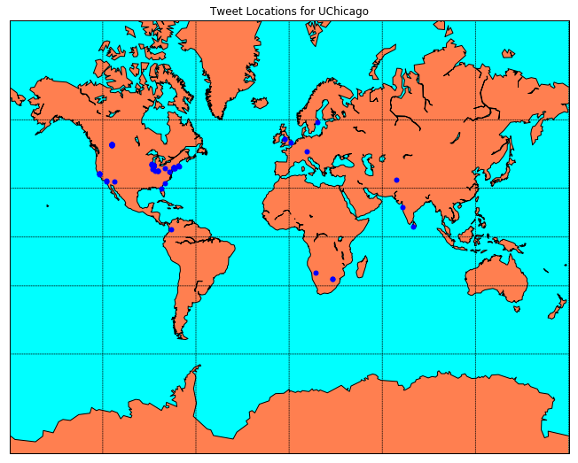

```python
# Define the projection, scale, the corners of the map, and the resolution.
m = Basemap(projection='merc',llcrnrlat=-80,urcrnrlat=80,\
            llcrnrlon=-180,urcrnrlon=180,lat_ts=20,resolution='c')
# Draw the coastlines
m.drawcoastlines()
# Color the continents
m.fillcontinents(color='coral',lake_color='aqua')
# draw parallels and meridians.
m.drawparallels(np.arange(-90.,91.,30.))
m.drawmeridians(np.arange(-180.,181.,60.))
# fill in the oceans
m.drawmapboundary(fill_color='aqua')
plt.title("Tweet Locations for UChicago")
# This is the step that transforms the data into the map's projection
x,y = m(lat, lon)
#adding on the colors to the map as per the number of tweets received from a particular place

m.plot(x,y, 'bo', markersize=5)
plt.show()
```

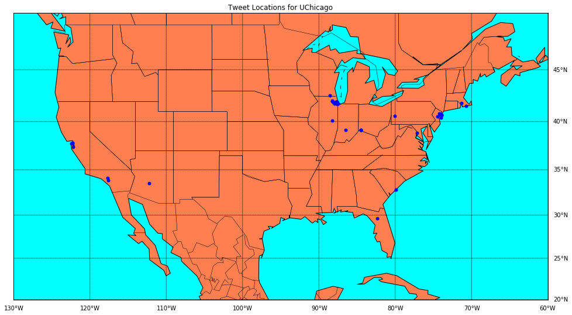

```python
#maps specifically for the US
# Define the projection, scale, the corners of the map, and the resolution.
m = Basemap(projection='merc',llcrnrlat=20,urcrnrlat=50,\
            llcrnrlon=-130,urcrnrlon=-60,lat_ts=20,resolution='c')
m.drawcoastlines()
m.drawcountries()
m.drawstates()
# draw parallels and meridians.
parallels = np.arange(-90.,91.,5.)
# Label the meridians and parallels
m.drawparallels(parallels,labels=[False,True,True,False])
# Draw Meridians and Labels
meridians = np.arange(-180.,181.,10.)
m.drawmeridians(meridians,labels=[True,False,False,True])
m.fillcontinents(color='coral',lake_color='aqua')
# fill in the oceans
m.drawmapboundary(fill_color='aqua')
plt.title("Tweet Locations for UChicago")
# This is the step that transforms the data into the map's projection
x,y = m(lat, lon)
#adding on the colors to the map as per the number of tweets received from a particular place

m.plot(x,y, 'bo', markersize=5)
plt.show()
```

#### Repeating the same analysis for Northwestern

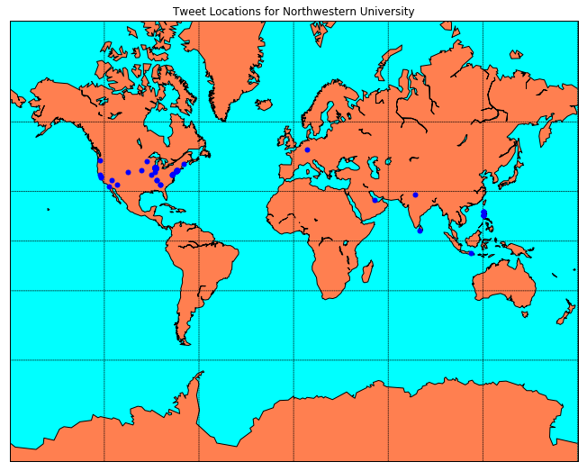

```python
#creating a grouped data set to calculate the number of tweets originating from a location
df_loc_tweet = df_concat[df_concat.College_ID=="Northwestern"].groupby('coordinates.coordinates',as_index=False)\
        ['text_clean'].count()\
        .sort_values('text_clean',ascending=False).reset_index(drop=True)\
        .rename(columns={"text_clean":"tweet_count", "coordinates.coordinates":"coor"})
##
df_loc_tweet[['coor','lon']] = df_loc_tweet['coor'].str.split(',',expand=True)
df_loc_tweet.rename(columns={"coor":"lat"})
##
df_loc_tweet['coor'] = df_loc_tweet['coor'].str[1:]
df_loc_tweet['lon'] = df_loc_tweet['lon'].str[:-1]
##
#preparing the lat and longitude data
lat=(pd.to_numeric(df_loc_tweet["coor"])).tolist()
lon=(pd.to_numeric(df_loc_tweet["lon"])).tolist()
##
tweet_count_list=df_loc_tweet["tweet_count"].tolist()

##creating the first chart
# Define the projection, scale, the corners of the map, and the resolution.
m = Basemap(projection='merc',llcrnrlat=-80,urcrnrlat=80,\
            llcrnrlon=-180,urcrnrlon=180,lat_ts=20,resolution='c')
# Draw the coastlines
m.drawcoastlines()
# Color the continents
m.fillcontinents(color='coral',lake_color='aqua')
# draw parallels and meridians.
m.drawparallels(np.arange(-90.,91.,30.))
m.drawmeridians(np.arange(-180.,181.,60.))
# fill in the oceans
m.drawmapboundary(fill_color='aqua')
plt.title("Tweet Locations for Northwestern University")
# This is the step that transforms the data into the map's projection
x,y = m(lat, lon)
#adding on the colors to the map as per the number of tweets received from a particular place

m.plot(x,y, 'bo', markersize=5)
plt.show()
```

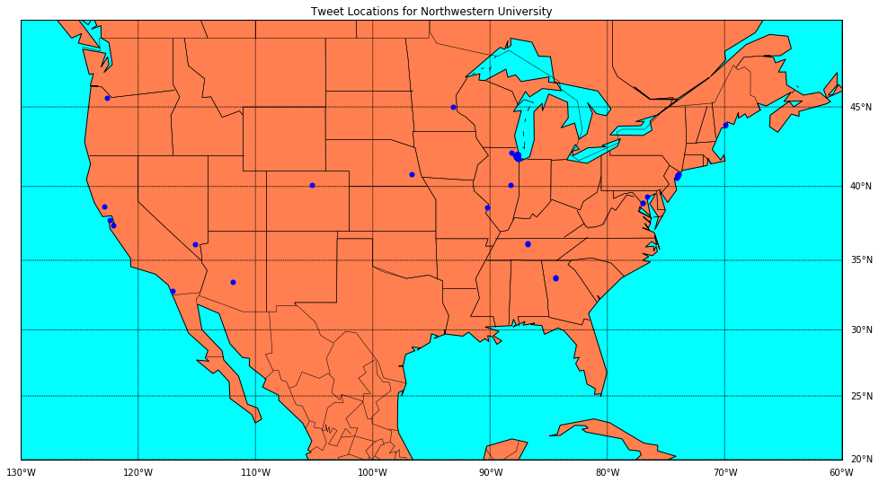

```python
# creating the second chart
#maps specifically for the US
# Define the projection, scale, the corners of the map, and the resolution.
m = Basemap(projection='merc',llcrnrlat=20,urcrnrlat=50,\
            llcrnrlon=-130,urcrnrlon=-60,lat_ts=20,resolution='c')
m.drawcoastlines()
m.drawcountries()
m.drawstates()
# draw parallels and meridians.
parallels = np.arange(-90.,91.,5.)
# Label the meridians and parallels
m.drawparallels(parallels,labels=[False,True,True,False])
# Draw Meridians and Labels
meridians = np.arange(-180.,181.,10.)
m.drawmeridians(meridians,labels=[True,False,False,True])
m.fillcontinents(color='coral',lake_color='aqua')
# fill in the oceans
m.drawmapboundary(fill_color='aqua')
plt.title("Tweet Locations for Northwestern University")
# This is the step that transforms the data into the map's projection
x,y = m(lat, lon)
#adding on the colors to the map as per the number of tweets received from a particular place

m.plot(x,y, 'bo', markersize=5)
plt.show()
```

## How unique are the messages about these universities?

- Are they mostly unique? Or mostly people are just posting about the same topic?
- You can use something like Jaccard similarity/Cosine Similarity/Simhash/Min hash to measure uniqueness / similarity
- Visualize message duplication

#### Calculating the number of duplicate tweets and if people are tweeting about the same issue

```python
dup_tweet_count=df_concat[df_concat.College_ID=="UChicago"].groupby(['text']).count()\
        .sort_values('user.screen_name',ascending=False).reset_index(drop=True)\
        .rename(columns={"user.screen_name":"repeated_tweets"})['repeated_tweets'].sub(1).sum()
print("Number of people who are tweeting about the same issue:",dup_tweet_count)
```

```
Number of people who are tweeting about the same issue: 69791
```

```python
#calculating the same for Northwestern
dup_tweet_count=df_concat[df_concat.College_ID=="Northwestern"].groupby(['text']).count()\
        .sort_values('user.screen_name',ascending=False).reset_index(drop=True)\
        .rename(columns={"user.screen_name":"repeated_tweets"})['repeated_tweets'].sub(1).sum()
print("Number of people who are tweeting about the same issue:",dup_tweet_count)
```

```
Number of people who are tweeting about the same issue: 35787
```

### Cleaning the data to process and use for building inferences

- Stemming: Stemming is a rudimentary rule-based process of stripping the suffixes (“ing”, “ly”, “es”, “s” etc) from a word.
- Lemmatization: Lemmatization, on the other hand, is an organized & step by step procedure of obtaining the root form of the word, it makes use of vocabulary (dictionary importance of words) and morphological analysis (word structure and grammar relations).

```python
UC_tweets=(df_concat[df_concat.College_ID=="UChicago"]).text_clean
NU_tweets=(df_concat[df_concat.College_ID=="Northwestern"]).text_clean
```

```python
from nltk.corpus import stopwords
from nltk.stem.wordnet import WordNetLemmatizer
import string
```

```python
stop = set(stopwords.words('english'))
exclude = set(string.punctuation)
lemma = WordNetLemmatizer()
def clean(doc):
    stop_free = " ".join([i for i in doc.lower().split() if i not in stop])
    punc_free = ''.join(ch for ch in stop_free if ch not in exclude)
    normalized = " ".join(lemma.lemmatize(word) for word in punc_free.split())
    return normalized
```

```python
UC_tweets_process = [clean(doc).split() for doc in UC_tweets]
```

```python
NU_tweets_process=[clean(doc).split() for doc in NU_tweets]
```

#### Analyzing the twitter sentiment

```python
from textblob import TextBlob
df_concat["sentiment"]=df_concat["text_clean"].apply(lambda x: TextBlob(x).sentiment[0])
```

```python
print(max(df_concat["sentiment"]), min(df_concat["sentiment"]))
```

```
1.0 -1.0
```

```python
#creating polarity brackets as per the polarity score obtained
df_concat['tweet_polarity'] = df_concat.apply(lambda x: 'Strong Positive'
                                      if x['sentiment']>=0.5 else 'Positive' if x['sentiment']>0 else 'Neutral'
                                                if x['sentiment']==0 else 'Negative' if x['sentiment']>=-0.5
                                                else 'Strong Negative', axis=1)
```

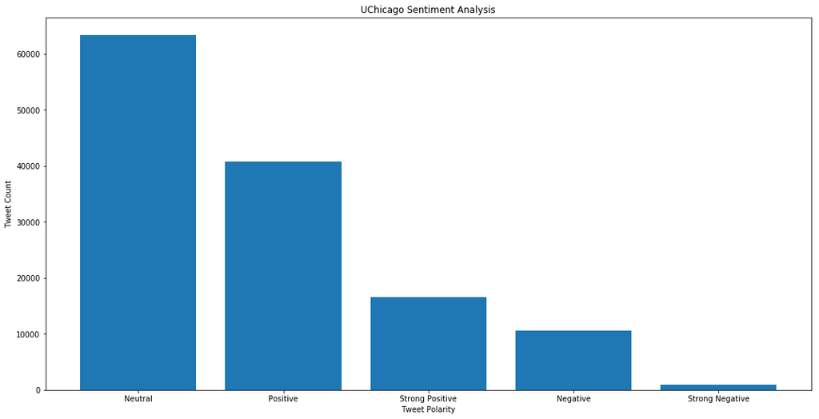

```python
#aggregating and creating charts for the above sentiment
sentiment_data=df_concat[df_concat.College_ID=="UChicago"].groupby(["tweet_polarity"],as_index=False)\
        ['text_clean'].count()\
        .sort_values('text_clean',ascending=False).reset_index(drop=True)\
        .rename(columns={"text_clean":"tweet_count"})
plt.bar(sentiment_data["tweet_polarity"],sentiment_data["tweet_count"])
plt.ylabel("Tweet Count")
plt.xlabel("Tweet Polarity")
plt.title("UChicago Sentiment Analysis")
plt.show()
```

### Repeating the same for Northwestern

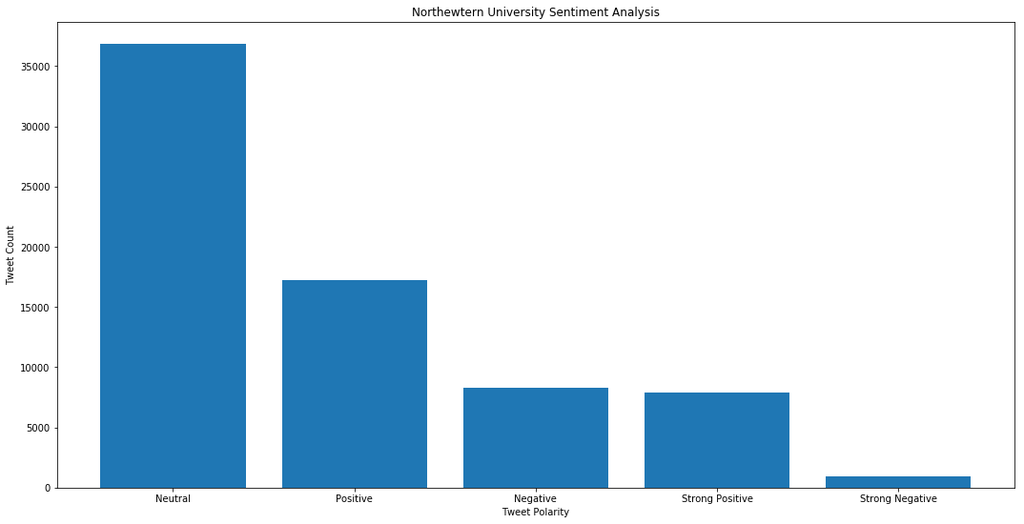

```python
#aggregating and creating charts for the above sentiment
sentiment_data=df_concat[df_concat.College_ID=="Northwestern"].groupby(["tweet_polarity"],as_index=False)\
        ['text_clean'].count()\
        .sort_values('text_clean',ascending=False).reset_index(drop=True)\
        .rename(columns={"text_clean":"tweet_count"})
plt.bar(sentiment_data["tweet_polarity"],sentiment_data["tweet_count"])
plt.ylabel("Tweet Count")
plt.xlabel("Tweet Polarity")
plt.title("Northewtern University Sentiment Analysis")
plt.show()
```

#### Checking Topic Modeling

Topic modeling is a process of automatically identifying the topics present in a text corpus, it derives the hidden patterns among the words in the corpus in an unsupervised manner. Topics are defined as “a repeating pattern of co-occurring terms in a corpus”. A good topic model results in – “health”, “doctor”, “patient”, “hospital” for a topic – Healthcare, and “farm”, “crops”, “wheat” for a topic – “Farming”.

```python
import gensim
from gensim import corpora
```

```python
# Creating the term dictionary of our corpus, where every unique term is assigned an index.
dictionary = corpora.Dictionary(UC_tweets_process)
```

```python
# Converting list of documents (corpus) into Document Term Matrix using dictionary prepared above.
tweet_term_matrix = [dictionary.doc2bow(doc) for doc in UC_tweets_process]
```

```python
# Creating the object for LDA model using gensim library
Lda = gensim.models.ldamodel.LdaModel
```

```python
# Running and Training LDA model on the document term matrix
ldamodel = Lda(tweet_term_matrix, num_topics=10, id2word = dictionary, passes=100)
```

```python
# Results
print(ldamodel.print_topics())
```

[output not shown]

#### Repeating the same analysis for NU

```python
# Converting list of documents (corpus) into Document Term Matrix using dictionary prepared above.
tweet_term_matrix_NU = [dictionary.doc2bow(doc) for doc in NU_tweets_process]
ldamodel_2 = Lda(tweet_term_matrix_NU, num_topics=10, id2word = dictionary, passes=100)
# Results
print(ldamodel_2.print_topics())
```

[output not shown]

```python
for i, topic in enumerate(ldamodel.print_topics(15)):
    print (i, topic)
```

```
0 (0, '0.059*"uchicago" + 0.046*"rt" + 0.030*"program" + 0.024*"california" + 0.020*"repeal" + 0.016*"team" + 0.009*"chicagomaroons" + 0.008*"1935" + 0.008*"archery" + 0.006*"book"')
1 (1, '0.042*"rt" + 0.039*"uchicago" + 0.021*"year" + 0.015*"uofc" + 0.013*"first" + 0.009*"uofcincy" + 0.007*"american" + 0.007*"ap" + 0.006*"woman" + 0.006*"great"')
2 (2, '0.051*"uchicago" + 0.029*"rt" + 0.015*"would" + 0.013*"tax" + 0.011*"uofc" + 0.010*"gop" + 0.009*"amp" + 0.008*"37" + 0.008*"38th" + 0.008*"happy"')
3 (3, '0.059*"uchicago" + 0.041*"rt" + 0.012*"amp" + 0.012*"new" + 0.011*"davidaxelrod" + 0.008*"student" + 0.008*"global" + 0.006*"cancer" + 0.006*"help" + 0.006*"study"')
4 (4, '0.060*"rt" + 0.054*"uchicago" + 0.045*"breaking" + 0.045*"news" + 0.041*"science" + 0.041*"richard" + 0.041*"thaler" + 0.038*"prize" + 0.038*"chicagobooth" + 0.036*"2017"')
5 (5, '0.096*"chicago" + 0.088*"university" + 0.063*"rt" + 0.063*"law" + 0.035*"school" + 0.031*"sofiaorden" + 0.027*"linguistics" + 0.023*"physic" + 0.022*"video" + 0.013*"institute"')
6 (6, '0.084*"chicago" + 0.070*"university" + 0.060*"rt" + 0.025*"economics" + 0.020*"student" + 0.018*"via" + 0.018*"booth" + 0.016*"biology" + 0.015*"dr" + 0.013*"human"')
7 (7, '0.135*"university" + 0.110*"chicago" + 0.062*"rt" + 0.031*"one" + 0.025*"economist" + 0.024*"daca" + 0.023*"haileysecretary" + 0.021*"unlawful" + 0.021*"httpstcoymrxme" + 0.021*"surveyed"')
8 (8, '0.068*"uchicago" + 0.044*"rt" + 0.019*"uchicagogsu" + 0.016*"grad" + 0.013*"student" + 0.010*"http" + 0.009*"union" + 0.008*"politics" + 0.007*"good" + 0.006*"full"')
9 (9, '0.055*"uchicago" + 0.054*"rt" + 0.033*"uofcalifornia" + 0.023*"trump" + 0.022*"administration" + 0.017*"research" + 0.012*"oh" + 0.012*"guy" + 0.011*"understand" + 0.010*"worker"')
```

```python
# Package is in detached-head mode. Clone from Github, commit latest changes and run setup.py
# https://github.com/bmabey/pyLDAvis
import pyLDAvis.gensim as gensimvis
import pyLDAvis
```

```python
vis_data = gensimvis.prepare(ldamodel, tweet_term_matrix, dictionary)
pyLDAvis.display(vis_data)
```

[interactive chart not shown]

```python
#checking the same for NU
vis_data = gensimvis.prepare(ldamodel_2, tweet_term_matrix_NU, dictionary)
pyLDAvis.display(vis_data)
```

[interactive chart not shown]

### Checking for cosine similarity

```python
#run this after cleaning your data and the pre-processing
import math
from collections import Counter
```

```python
def text_to_vector(text):
    words = text.split()
    return Counter(words)
```

```python
UC_tweet_list=list(df_concat[df_concat.College_ID=="UChicago"].text_clean)
UC_tweet_list[1:5]
```

```
['the four uchicago dress senses: business casual 25, unrepentant STEMlord 20, gay ascetic 10, seinfeld extra 45',
 'RT @HdxAcademy: We congratulate @UChicago amp Pres R. Zimmer on their top rating in our Guide to Colleges: Top 150 Universities: ',
 'Great visit from @UChicago students #PaulSereno lab Exhibits, #histology #anagensis #dinosaurs FUN w https:t.cobyatkv4uth',
 '#thursdaythought: Shadowing attorneys this week, I felt connected to the Centers clients and their stories.Emma Gardner @UChicago intern']
```

```python
iter_no=len(UC_tweet_list)
print(iter_no)
```

```
132164
```

```python
def cosine_similarity():
    num_total=0
    deno_total=0
    #vec1=numeric()
    #vec2=numeric()
    for i in range(10):
        #vector[i]=text_to_vector(UC_tweet_list[i])
        vec1 = text_to_vector(UC_tweet_list[i])
        for j in range(iter_no-1):
            #vector_2[j+1]=)
            vec2 = text_to_vector(UC_tweet_list[j+1])

            common = set(vec1.keys()) & set(vec2.keys())
            numerator = sum([vec1[x] * vec2[x] for x in common])
            num_total +=numerator

            sum1 = sum([vec1[x]**2 for x in vec1.keys()])
            sum2 = sum([vec2[x]**2 for x in vec2.keys()])
            denominator = math.sqrt(sum1) * math.sqrt(sum2)
            deno_total +=denominator

    if not deno_total:
        return 0.0
    else:
        return float(num_total) / deno_total
```

```python
cosine_similarity()
```

```
0.05030496418313897
```

### Performing the same analysis for Northwestern

```python
UC_tweet_list=list(df_concat[df_concat.College_ID=="Northwestern"].text_clean)

iter_no=len(UC_tweet_list)
print(iter_no)

cosine_similarity()
```

```
71193
```

```
0.06359801423392099
```